# Association rules

Movie recommender systems

Mina Moosavifar - 93106788

2018-07-20 19:54:07

[figure not shown]

> با استفاده از داده نظرهای فیلم به سوالات زیر پاسخ دهید.

بارگذاری داده ها و کتابخانه ها:

```r
library(readr)
library(dplyr)
library(ggplot2)
library(highcharter)
library(stringr)

# Movies
movie = read_delim('data/ml-10M100K/movies.dat',delim = "::" ,col_names = c("MovieID",NA,"Title",NA,"Genres"))
movie = movie %>% select(1,3,5)

# Tags
tag = read_delim('data/ml-10M100K/tags.dat',delim = "::" ,col_names = c("UserID",NA,"MovieID",NA,"Tag",NA,"Timestamp"))
tag = tag %>% select(1,3,5,7)

# Ratings
rating = read_delim('data/ml-10M100K/ratings.dat',delim = "::" ,col_names = c("UserID",NA,"MovieID",NA,"Rating",NA,"Timestamp"))
rating = rating %>% select(1,3,5,7)
```

۱. آماره های زیر را بیابید.  
**الف. محبوب ترین فیلم کدام است؟**  
محبوب ترین فیلم را فیلمی در نظر میگیریم که بیشتر از ۱۰۰۰ نفر آن را دیده باشند و در عین حال rating بالایی نیز داشته باشد.

```r
# a: best rated movie
best_rate <- rating %>% filter(!is.na(Rating)) %>%
  group_by(MovieID) %>% summarise(Rate = mean(Rating), watch = n()) %>%
  filter(watch > 1000) %>% arrange(desc(Rate)) %>%
  left_join(movie, by = c("MovieID")) %>%
  slice(1:10)

knitr::kable(best_rate)
```

| MovieID | Rate | watch | Title | Genres |
| --- | --- | --- | --- | --- |
| 318 | 4.457238 | 31126 | Shawshank Redemption, The (1994) | Drama |
| 858 | 4.415085 | 19814 | Godfather, The (1972) | Crime\|Drama |
| 50 | 4.367142 | 24037 | Usual Suspects, The (1995) | Crime\|Mystery\|Thriller |
| 527 | 4.363483 | 25777 | Schindler’s List (1993) | Drama\|War |
| 922 | 4.321966 | 3255 | Sunset Blvd. (a.k.a. Sunset Boulevard) (1950) | Drama\|Film-Noir\|Romance |
| 912 | 4.319741 | 12507 | Casablanca (1942) | Drama\|Romance |
| 904 | 4.316544 | 8825 | Rear Window (1954) | Mystery\|Thriller |
| 3435 | 4.315439 | 2403 | Double Indemnity (1944) | Crime\|Drama\|Film-Noir |
| 2019 | 4.314119 | 5751 | Seven Samurai (Shichinin no samurai) (1954) | Action\|Drama |
| 1212 | 4.313629 | 3265 | Third Man, The (1949) | Film-Noir\|Mystery\|Thriller |

**ب. بیشترین نظرات درباره چه فیلمی داده شده است؟**

```r
# b: most reviewed movie
most_rev <- tag %>% filter(!is.na(MovieID)) %>%
  group_by(MovieID) %>%
  summarise(Review = n()) %>%
  arrange(desc(Review)) %>%
  left_join(movie, by = c("MovieID")) %>%
  slice(1:10)

knitr::kable(most_rev)
```

| MovieID | Review | Title | Genres |
| --- | --- | --- | --- |
| 296 | 308 | Pulp Fiction (1994) | Comedy\|Crime\|Drama |
| 318 | 257 | Shawshank Redemption, The (1994) | Drama |
| 2959 | 233 | Fight Club (1999) | Action\|Crime\|Drama\|Thriller |
| 527 | 232 | Schindler’s List (1993) | Drama\|War |
| 260 | 223 | Star Wars | NA |
| 7361 | 221 | Eternal Sunshine of the Spotless Mind (2004) | Comedy\|Drama\|Romance\|Sci-Fi |
| 2571 | 220 | Matrix, The (1999) | Action\|Sci-Fi\|Thriller |
| 858 | 205 | Godfather, The (1972) | Crime\|Drama |
| 44191 | 204 | V for Vendetta (2006) | Thriller |
| 593 | 203 | Silence of the Lambs, The (1991) | Crime\|Horror\|Thriller |

**پ. منفورترین فیلم کدام است؟**  
منفورترین فیلم را فیلمی در نظر میگیریم که بیشتر از ۵۰۰ نفر آن را دیده باشند و در عین حال rating بسیار کمی داشته باشد.

```r
# c: most hated movie
worst_rate <- rating %>% filter(!is.na(Rating)) %>%
  group_by(MovieID) %>% summarise(Rate = mean(Rating), watch = n()) %>%
  filter(watch > 500) %>% arrange(Rate) %>%
  left_join(movie, by = c("MovieID")) %>%
  slice(1:10)

knitr::kable(worst_rate)
```

| MovieID | Rate | watch | Title | Genres |
| --- | --- | --- | --- | --- |
| 3593 | 1.577703 | 2072 | Battlefield Earth (2000) | Action\|Sci-Fi |
| 1595 | 1.673713 | 544 | Free Willy 3 | NA |
| 2555 | 1.692819 | 752 | Baby Geniuses (1999) | Comedy |
| 3268 | 1.694653 | 1066 | Stop! Or My Mom Will Shoot (1992) | Action\|Comedy |
| 2807 | 1.709066 | 739 | Universal Soldier | NA |
| 3799 | 1.717514 | 531 | Pokémon the Movie 2000 (2000) | Animation\|Children |
| 2799 | 1.725155 | 644 | Problem Child 2 (1991) | Comedy |
| 1981 | 1.727471 | 688 | Friday the 13th Part VIII | NA |
| 2383 | 1.727833 | 1218 | Police Academy 6 | NA |
| 6482 | 1.737171 | 721 | Dumb and Dumberer | NA |

**ت. تعداد فیلم های ساخته شده در هر سال**  
برای حل این سوال می بایست ابتدا سال فیلم را از طریق regex بدست بیاوریم و سپس بر اساس سال گروه بندی کنیم و نمودار را بکشیم.

```r
# d: yearly built movies
movie <- movie %>% mutate(year = str_extract(Title, '\\([[:digit:]]{4}\\)'))
yearly <- movie %>% group_by(year) %>% summarise(count = n()) %>% filter(!is.na(year))

yearly  %>% mutate(year = str_extract(year, '[[:digit:]]{4}')) %>%
  hchart(type = "line", hcaes(x = year, y = count)) %>%
  hc_yAxis(title = list(text = "Count")) %>%
  hc_xAxis(title = list(text = "Year")) %>%
  hc_title(text = "Number of Movie Produced Yearly", style = list(fontWeight = "bold")) %>%
  hc_add_theme(hc_theme_sandsignika())
```

[interactive chart not shown]

**ث. در هر سالی مردم به چه ژانری علاقه مند بوده اند.**  
برای حل این سوال ابتدا ژانر هر فیلم را بدست می آوریم. برای این منظور، ابتدا تمامی ژانرهای ممکن را استخراج کرده و آن را تبدیل به ستون می کنیم. حال در صورتی که فیلمی در این ژانر باشد مقدار آن ستون را برابر با یک قرار می دهیم. سپس rating هر فیلم را نیز به این داده اضافه می کنیم. در نهایت در هر سال فیلم هایی که بیشتر از ۱۰۰ نفر آن را دیده باشند و امتیاز بالای ۳ داشته باشند را به عنوان فیلم های محبوب مردم در نظر میگیریم. در انتها می بایست ژانری که بیشترین فیلم مورد علاقه دارد را بدست آوریم که برای این کار ابتدا بر اساس سال گروه بندی کرده و سپس مجموع ستون های ژانرها را حساب می کنیم و ژانری که بیشترین مجموع را داشته باشد، بیشترین فیلم محبوب را در خود جا داده و در نتیجه محبوب ترین ژانر حساب می شود.

```r
# e: favourite genre

# extract genre for each movie
movie_genre <- movie
movie_genre$Action = 0
movie_genre$Adventure = 0
movie_genre$Animation = 0
movie_genre$Children = 0
movie_genre$Comedy = 0
movie_genre$Crime = 0
movie_genre$Documentary = 0
movie_genre$Drama = 0
movie_genre$Fantasy = 0
movie_genre$`Film-Noir` = 0
movie_genre$Horror = 0
movie_genre$Musical = 0
movie_genre$Mystery = 0
movie_genre$Romance = 0
movie_genre$`Sci-Fi` = 0
movie_genre$Thriller = 0
movie_genre$War = 0
movie_genre$Western = 0

movie_genre <- movie_genre %>%
  mutate(Action = ifelse(str_detect(Genres, 'Action'),1,0),
         Adventure = ifelse(str_detect(Genres, 'Adventure'),1,0),
         Animation = ifelse(str_detect(Genres, 'Animation'),1,0),
         Children = ifelse(str_detect(Genres, 'Children'),1,0),
         Comedy = ifelse(str_detect(Genres, 'Comedy'),1,0),
         Crime = ifelse(str_detect(Genres, 'Crime'),1,0),
         Documentary = ifelse(str_detect(Genres, 'Documentary'),1,0),
         Drama = ifelse(str_detect(Genres, 'Drama'),1,0),
         Fantasy = ifelse(str_detect(Genres, 'Fantasy'),1,0),
         `Film-Noir` = ifelse(str_detect(Genres, 'Film-Noir'),1,0),
         Horror = ifelse(str_detect(Genres, 'Horror'),1,0),
         Musical = ifelse(str_detect(Genres, 'Musical'),1,0),
         Mystery = ifelse(str_detect(Genres, 'Mystery'),1,0),
         Romance = ifelse(str_detect(Genres, 'Romance'),1,0),
         `Sci-Fi` = ifelse(str_detect(Genres, 'Sci-Fi'),1,0),
         Thriller = ifelse(str_detect(Genres, 'Thriller'),1,0),
         War = ifelse(str_detect(Genres, 'War'),1,0),
         Western = ifelse(str_detect(Genres, 'Western'),1,0))
movie_genre <- na.omit(movie_genre)

movie_genre <- rating %>% filter(!is.na(Rating)) %>%
  group_by(MovieID) %>% summarise(Rate = mean(Rating), watch = n()) %>%
  left_join(movie_genre, by = c("MovieID"))
movie_genre <- na.omit(movie_genre)

yearly_genre <- movie_genre %>% filter(watch > 100 & Rate > 3) %>%
  group_by(year) %>% summarise_at(c(7:23), sum)
yearly_genre <- na.omit(yearly_genre)

yearly_genre$chosen <- colnames(yearly_genre %>%
                                  select(-year))[max.col(yearly_genre %>%
                                                           select(-year),ties.method="first")]
knitr::kable(yearly_genre %>% select(year, chosen))
```

| year | chosen |
| --- | --- |
| (1915) | Drama |
| (1920) | Crime |
| (1921) | Comedy |
| (1922) | Horror |
| (1923) | Comedy |
| (1924) | Comedy |
| (1925) | Adventure |
| (1926) | Drama |
| (1927) | Drama |
| (1928) | Comedy |
| (1929) | Musical |
| (1930) | Drama |
| (1931) | Drama |
| (1932) | Drama |
| (1933) | Horror |
| (1934) | Comedy |
| (1935) | Drama |
| (1936) | Comedy |
| (1937) | Drama |
| (1938) | Drama |
| (1939) | Drama |
| (1940) | Comedy |
| (1941) | Drama |
| (1942) | Drama |
| (1943) | Drama |
| (1944) | Drama |
| (1945) | Drama |
| (1946) | Drama |
| (1947) | Drama |
| (1948) | Drama |

[output cut: 60 more lines]

۲. ژانر فیلم ها را استخراج نمایید. سپس آماره های زیر را استخراج نمایید.  
این داده در بخش آخر سوال پیش با نام movie_genre طبق توضیحات داده ساخته شده است.  
**الف. نمودار ستونی تعداد فیلم های هر ژانر**  
برای این سوال ابتدا داده ی فوق را به صورت مجموع هر ستون خلاصه سازی می کنیم. در نهایت با کمک تابع melt ستون های دیتافریم را تبدیل به ردیف می کنیم و نمودار را نمایش می دهیم.

```r
library(reshape2)

# a: count of genre movies
count_genre <- movie_genre  %>% summarise_at(c(7:24), sum)
count_genre = melt(count_genre)
colnames(count_genre) = c('genre', 'count')

count_genre %>% arrange(desc(count)) %>%
  hchart(type = "column", hcaes(x = genre, y = count, color = count)) %>%
  hc_yAxis(title = list(text = "Count")) %>%
  hc_xAxis(title = list(text = "Genre")) %>%
  hc_title(text = "Number of Movie Produced in Each Genre", style = list(fontWeight = "bold")) %>%
  hc_add_theme(hc_theme_538())
```

[interactive chart not shown]

**ب. نمودار همبستگی ژانرها**

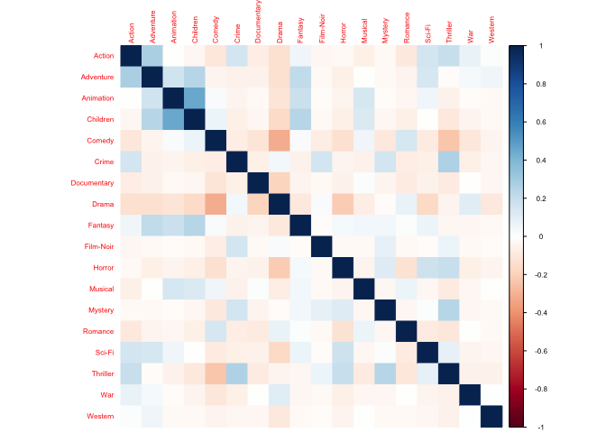

```r
# b: genres correlation plot
library(corrplot)
corrplot(cor(movie_genre  %>% select(c(7:24))), method = "color", tl.cex = 0.5/par("cex"), cl.cex = 0.5/par("cex"))
```

**پ. متوسط امتیاز به هر ژانر**  
برای حل این سوال، ابتدا امتیاز فیلم در هر ژانر را برای آن ژانر قرار می دهیم. سپس مجموع ستون ها را بدست آورده و آن را تقسیم بر تعداد فیلم های ساخته شده در هر ژانر که در بخش الف بدست آوردیم می کنیم و میانگین امتیاز هر ژانر را بدست می آوریم. در نهایت نیز دیتافریم را به کمک melt از ستونی به سطری تبدیل می کنیم.

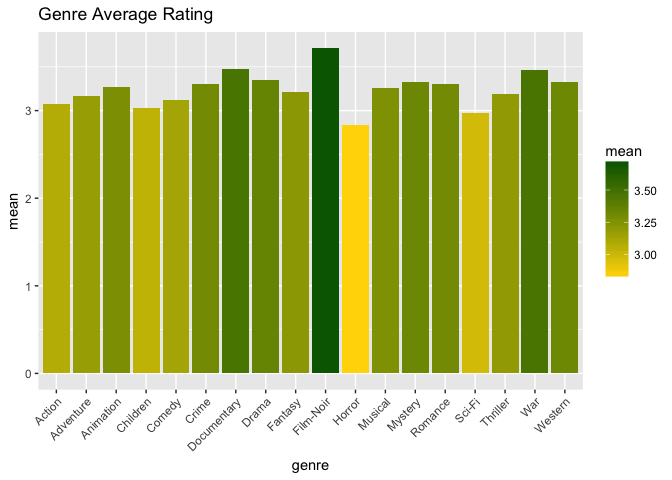

```r
# c: average rating for genres
library(ggplot2)

rate_genre <- movie_genre %>%
  mutate(Action = Rate*Action,
         Adventure = Rate*Adventure,
         Animation = Rate*Animation,
         Children = Rate*Children,
         Comedy = Rate*Comedy,
         Crime = Rate*Crime,
         Documentary = Rate*Documentary,
         Drama = Rate*Drama ,
         Fantasy = Rate*Fantasy,
         `Film-Noir` = Rate*`Film-Noir`,
         Horror = Rate*Horror,
         Musical = Rate*Musical,
         Mystery = Rate*Mystery,
         Romance = Rate*Romance,
         `Sci-Fi` = Rate*`Sci-Fi`,
         Thriller = Rate*Thriller,
         War = Rate*War,
         Western = Rate*Western)

rate_sum_genre <- rate_genre %>% summarise_at(c(7:24), sum)
count_genre <- movie_genre  %>% summarise_at(c(7:24), sum)

rate_mean_genre <- rate_sum_genre/count_genre
mrate_mean_genre = melt(rate_mean_genre)
colnames(mrate_mean_genre) = c('genre', 'mean')

p = ggplot(data = mrate_mean_genre, mapping = aes(x = genre, y = mean, fill = mean)) +
  ggtitle("Genre Average Rating") + geom_bar(stat="identity") +
  scale_fill_gradient(low="gold", high="darkgreen") +
  theme(axis.text.x = element_text(angle = 45, hjust = 1))
p
```

```r
knitr::kable(mrate_mean_genre)
```

| genre | mean |
| --- | --- |
| Action | 3.072595 |
| Adventure | 3.170120 |
| Animation | 3.267474 |
| Children | 3.033140 |
| Comedy | 3.125286 |
| Crime | 3.301038 |
| Documentary | 3.471274 |
| Drama | 3.353767 |
| Fantasy | 3.212520 |
| Film-Noir | 3.711190 |
| Horror | 2.834151 |
| Musical | 3.260086 |
| Mystery | 3.330124 |
| Romance | 3.299617 |
| Sci-Fi | 2.969613 |
| Thriller | 3.189367 |
| War | 3.465174 |
| Western | 3.322971 |

**ت. دوران طلایی فیلم سازی**  
برای بدست آوردن دوران طلایی سینما، دهه ی هر فیلم را بدست آورده و بر اساس دهه گروه بندی کرده و دهه ای که بیشترین میانگین امتیاز را دارد را به عنوان دوران طلایی معرفی می کنیم.

```r
# d: cinema golden age
movie_rate <- movie_genre %>% select(-c(7:24)) %>%
  mutate(year = as.numeric(str_extract(year, '[[:digit:]]{4}'))) %>%
  mutate(decade = year - (year %% 10)) %>%
  group_by(decade) %>% summarise(watch_mean = mean(watch), watch = sum(watch), rate_mean = mean(Rate)) %>%
  arrange(desc(rate_mean))

golden_age <- movie_rate %>% slice(1)
cat("Cinema Golden Age is", golden_age[1,1,1], "with rating mean of", golden_age[1,4,1])
```

```
Cinema Golden Age is 1930 with rating mean of 3.531399
```

```r
movie_rate  %>% arrange(decade) %>%
  hchart(type = "line", hcaes(x = decade, y = rate_mean)) %>%
  hc_yAxis(title = list(text = "Average Rating")) %>%
  hc_xAxis(title = list(text = "Decade")) %>%
  hc_title(text = "Rating Average in Decades", style = list(fontWeight = "bold")) %>%
  hc_add_theme(hc_theme_flat())
```

[interactive chart not shown]

۳. نمودار ابر لغات را بر حسب کلمات عنوان فیلم ها رسم نمایید.

برای حل این سوال ابتدا زیرمجموعه ای از داده ی movies که تنها شامل عنوان فیلم هاست میگیریم. سپس نشانه گذاری ها را حذف کرده و عناوین را به کمک space تقسیم می کنیم. سپس فرکانس هر لغت را بدست می یابیم. در نهایت داده های غلط از جمله stopwords و سال ها و پرانتزها را حذف می کنیم و تصویر را به صورت یک دوربین فیلم برداری می کشیم.

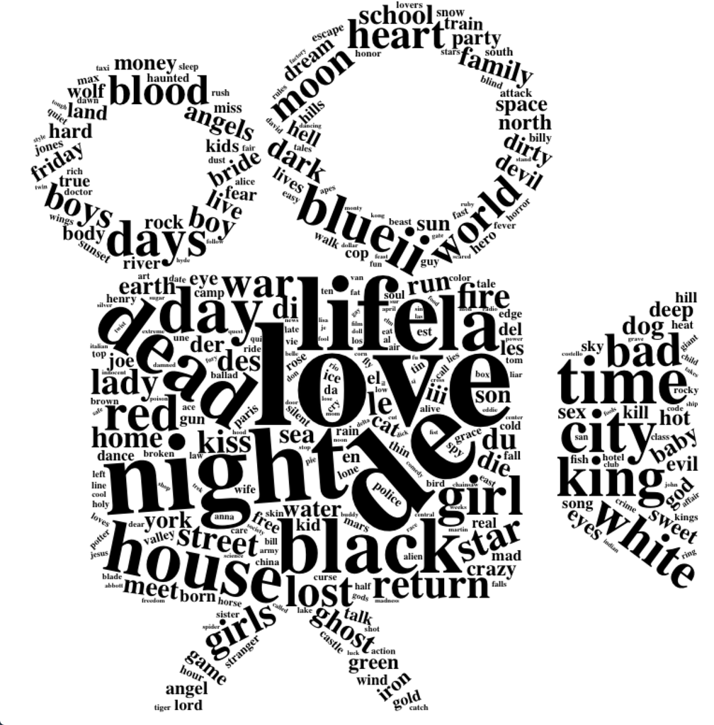

```r
library(wordcloud2)
library(tidytext)

title_data <- movie %>% select(text = Title) %>% mutate(text = str_to_lower(text)) %>%
  str_replace_all("\"","") %>%
  str_replace("[[:punct:]]", "") %>%
  str_split(pattern = "\\s") %>%
  unlist() %>% as.data.frame(stringsAsFactors = F) %>%
  filter( . != "")


title_data <- title_data %>% table() %>%
  as.data.frame(stringsAsFactors = F)

colnames(title_data) = c("word","count")

title_data <- title_data %>%
  filter(!word %in% stop_words$word) %>%
  filter(str_length(word)>1) %>%
  filter(!str_detect(word,"\\d")) %>%
  filter(!str_detect(word,"\\(")) %>%
  filter(!str_detect(word,"[[:punct:]]")) %>%
  arrange(desc(count)) %>%
  filter(count > 4) %>%
  select(word, freq = count)

wordcloud2(title_data , figPath = "images/movie-projector.png" , size = 0.9, color = "black")
```

۴. با استفاده از قوانین همبستگی یک توصیه گر برای فیلم ها بسازید. شبیه ترین فیلم ها به لیست زیر را پیدا کنید.

- Castle in the Sky (1986)
- Cast Away (2000)
- No Country for Old Men (2007)
- Memento (2000)

```r
library(arules)

transact <- rating %>% filter(Rating > 2.5) %>% select(UserID, MovieID)
user_item_matrix <- as(split(transact$MovieID, transact[,"UserID"]), "transactions")
user_item_matrix
```

```
transactions in sparse format with
 69863 transactions (rows) and
 10598 items (columns)
```

```r
parameters = list(
  supp = 0.001,
  conf = 0.7,
  maxlen = 2
)
association_rules = apriori(user_item_matrix,parameter = parameters)
```

```
Apriori

Parameter specification:
 confidence minval smax arem  aval originalSupport maxtime support minlen
        0.7    0.1    1 none FALSE            TRUE       5   0.001      1
 maxlen target   ext
      2  rules FALSE

Algorithmic control:
 filter tree heap memopt load sort verbose
    0.1 TRUE TRUE  FALSE TRUE    2    TRUE

Absolute minimum support count: 69

set item appearances ...[0 item(s)] done [0.00s].
set transactions ...[10598 item(s), 69863 transaction(s)] done [1.23s].
sorting and recoding items ... [5891 item(s)] done [0.23s].
creating transaction tree ... done [0.08s].
checking subsets of size 1 2 done [3.23s].
writing ... [78652 rule(s)] done [0.13s].
creating S4 object  ... done [0.07s].
```

```r
summary(association_rules)
```

```
set of 78652 rules

rule length distribution (lhs + rhs):sizes
    2
78652

   Min. 1st Qu.  Median    Mean 3rd Qu.    Max.
      2       2       2       2       2       2

summary of quality measures:
    support           confidence          lift             count
 Min.   :0.001002   Min.   :0.7000   Min.   :  1.510   Min.   :   70.0
 1st Qu.:0.001546   1st Qu.:0.7214   1st Qu.:  2.211   1st Qu.:  108.0
 Median :0.002763   Median :0.7477   Median :  2.922   Median :  193.0
 Mean   :0.007531   Mean   :0.7576   Mean   :  3.785   Mean   :  526.2
 3rd Qu.:0.006685   3rd Qu.:0.7843   3rd Qu.:  4.268   3rd Qu.:  467.0
 Max.   :0.330060   Max.   :0.9754   Max.   :407.251   Max.   :23059.0

mining info:
             data ntransactions support confidence
 user_item_matrix         69863   0.001        0.7
```

```r
association_rules = subset(association_rules, lift >= 3.785)
summary(association_rules)
```

```
set of 26548 rules

rule length distribution (lhs + rhs):sizes
    2
26548

   Min. 1st Qu.  Median    Mean 3rd Qu.    Max.
      2       2       2       2       2       2

summary of quality measures:
    support           confidence          lift             count
 Min.   :0.001002   Min.   :0.7000   Min.   :  3.785   Min.   :   70.0
 1st Qu.:0.001345   1st Qu.:0.7204   1st Qu.:  4.247   1st Qu.:   94.0
 Median :0.002061   Median :0.7461   Median :  4.998   Median :  144.0
 Mean   :0.004258   Mean   :0.7568   Mean   :  6.350   Mean   :  297.5
 3rd Qu.:0.004094   3rd Qu.:0.7839   3rd Qu.:  6.255   3rd Qu.:  286.0
 Max.   :0.163706   Max.   :0.9754   Max.   :407.251   Max.   :11437.0

mining info:
             data ntransactions support confidence
 user_item_matrix         69863   0.001        0.7
```

```r
movie_recs <- association_rules %>% as(., "data.frame") %>%
  mutate(lhs = as.numeric(str_extract(rules, "[[:digit:]]+")),
         rhs = as.numeric(str_extract(str_extract(rules, " \\{[[:digit:]]+"), "[[:digit:]]+"))) %>%
  mutate(MovieID = lhs) %>% select(-lhs) %>%
  inner_join(movie %>% select(MovieID, Title), by = c("MovieID")) %>%
  mutate(lhs = MovieID, lhs_title = Title) %>% select(-MovieID, -Title) %>%
  mutate(MovieID = rhs) %>% select(-rhs) %>%
  inner_join(movie %>% select(MovieID, Title), by = c("MovieID")) %>%
  mutate(rhs = MovieID, rhs_title = Title) %>% select(-MovieID, -Title) %>%
  filter(lhs_title == "Castle in the Sky (Tenkû no shiro Rapyuta) (1986)" | lhs_title == "Cast Away (2000)" |
           lhs_title == "No Country for Old Men (2007)" | lhs_title == "Memento (2000)" |
           rhs_title == "Castle in the Sky (Tenkû no shiro Rapyuta) (1986)" | rhs_title == "Cast Away (2000)" |
           rhs_title == "No Country for Old Men (2007)" | rhs_title == "Memento (2000)") %>%
  group_by(rhs) %>%
  arrange(desc(lift)) %>%
  slice(1) %>%
  group_by(lhs) %>%
  arrange(desc(lift)) %>%
  slice(1) %>%
  ungroup()

movie_r <- bind_rows(movie_recs %>% filter(rhs_title == "Cast Away (2000)" | rhs_title == "No Country for Old Men (2007)" | rhs_title == "Memento (2000)") %>%
  select(Movie = rhs_title, Recommended = lhs_title),
  movie_recs %>% filter(lhs_title == "Castle in the Sky (Tenkû no shiro Rapyuta) (1986)") %>%
  select(Movie = lhs_title, Recommended = rhs_title))

knitr::kable(movie_r)
```

| Movie | Recommended |
| --- | --- |
| Memento (2000) | Following (1998) |
| Cast Away (2000) | Blaze (1989) |
| No Country for Old Men (2007) | Before the Devil Knows You’re Dead (2007) |
| Castle in the Sky (Tenkû no shiro Rapyuta) (1986) | Princess Mononoke (Mononoke-hime) (1997) |

۵. تمرین سخت: در گیت هاب برای خود اکانت درست کنید. همه تمرین های خود را آنجا بارگذاری کنید! و لینک آن را ارسال نمایید.

من ازابتدای درس، تمارین را در گیت هاب قرار می دادم:))  
https://github.com/minam75/Data_Analysis_HW

۶. پنج انتقاد از درس و نحوه تدریس را بیان کنید.

۱. درس به صورت کاملا مهندسی وار تدریس میشد و تمارین نیز به همین شکل بودند، اما ارزیابی درس کامل به صورت ریاضی وار بود.  
۲. بسیاری از اوقات متن تمارین خواسته ی واضح و متن روانی نداشت.  
۳. در طول ترم هیچ نمره ای اعلام نشد تا بتوانیم ارزیابی از خودمان داشته باشیم.  
۴. پس از حل ۹ سوال، سوال آخر تمارین کمی آزاردهنده بود. زیرا ۱۲ سری تمرین به صورت هفتگی فشار کمی نیست.  
۵. انتقاد دیگه ای نیست، شیوه ی تدریس درس که تعاملی بود خیلی مناسب بود.

۷. پنج پیشنهاد برای بهتر شدن درس بیان کنید.

۸. سه موضوع آماری جدید برای جایگزینی در سرفصل ها پیشنهاد دهید.

۱. Bayes Network  
۲. مباحث اضافه ای در dimentionality reduction  
۳. آشنایی با شبکه عصبی

۹. سه داده جالب برای کار در کلاس پیشنهاد دهید.

۱. Skytrax User Review of airlines  
۲. Amazon reviews  
۳. Ling-Spam Dataset - classifying spam from legitimate email  
لینک : https://en.wikipedia.org/wiki/List_of_datasets_for_machine_learning_research#Open_Repositories_2

۱۰. چهار نکته مهمی که در کلاس یاد گرفتید را بیان کنید.

۱. قبل از پیاده کردن هر ایده ای روی داده، اون رو تحلیل مکاشفه ای بکنم که هم با خود داده بیشتر آشنا بشم و هم اینکه شاید بدون نیاز به روش های پیچیده سوال قابل حل باشه.  
۲. به visualization دقت بکنم و سعی کنم نمودار مناسب رو بنا به داده و مفهومی که می خوام برسونم پیدا بکنم.  
۳. آزمون فرض  
۴. R به مقدار خیلی زیاد